# ETC5512: Solution for Tutorial 5

Belinda Maher

Week 5

## 🎯 Objectives

In this tutorial, you will learn

- how to load and manipulate data from an Excel file with sheets
- work with tidyverse wrangling verbs to summarise the data and recalculate measures at different levels of aggregation
- practise plotting using ggplot2 to make big picture inferences about the data

## 🔧 Data Preparation

Use this code to process the data from the spreadsheet. Try to understand what the code is doing at each step

```r
suppressPackageStartupMessages(library(tidyverse))
suppressPackageStartupMessages(library(here))
library(readxl)
library(purrr)
suppressPackageStartupMessages(library(magrittr))
suppressPackageStartupMessages(library(curl))

#Save the file
url<-"https://wcd.numbat.space/lectures/data/lecture-05/Rail%20PT%20Public%20Monthly%20Figures%20cleaned.xlsx"
if(!file.exists(here("Rail PT Public Monthly Figures cleaned.xlsx"))){
curl_download(url, here("Rail PT Public Monthly Figures cleaned.xlsx"))}

#or adjust this line to where you have saved the file (you might need to add *'folder','subfolder',* depending on where you have saved the file)
filename <- here('Rail PT Public Monthly Figures cleaned.xlsx')
sheets <- excel_sheets(filename)
perf <- map(sheets, ~read_xlsx(filename, sheet=.x))

#Name the sheets in the list by
names(perf)<-sheets

#Create a list of variables which you want to keep
keep<-c("Parent_Route","Mode","Service_Year", "Service_Date", "Service_Month",
       "Reporting_Group","num_services_scheduled","num_services_cancelled","num_services_short","num_services_bypassed","num_services_scheduled_at_dest","num_services_on_time_at_dest","num_observations_on_time","num_observations_scheduled", "pct_on_time_avg")
#These lines make sure that the data is in the correct format as it is read in from the sheet (not as character).
perf$Yarra$pct_on_time_at_dest%<>% as.numeric()
perf$Yarra$pct_not_on_time_at_dest%<>% as.numeric()
perf$Yarra$pct_on_time_avg%<>% as.numeric()
```

Don’t worry about “NAs introduced by coercion” errors the above code raises - this is because there are missing values in the data where City Shuttle (City Circle) services are not measured for on time running, so forcing the data to numeric leads to NAs where data points are not present, instead of the numeric data reading in as text.

```r
#stick all 3 sheets together into one data frame from a list
performance <- dplyr::bind_rows(perf, .id="Mode")

#remove extra columns not used (you may want to edit the 'keep' list if you want to look at detailed data at route level)
performance <- dplyr::select(performance,all_of(keep))
```

## 1. 💻 Load data and understand the process

**Question: What does the *.id=“Mode”* command do here?**

**Answer: It takes the names of each of the the lists (which came from the Excel sheet names) and adds them as a variable called “Mode” so you know which type of transport each data point came from when they are put together in one data frame.**

👀 Have a look at the data:

```r
View(performance)
```

```r
head(performance)
```

```
## # A tibble: 6 x 15
##   Parent_Route  Mode  Service_Year Service_Date        Service_Month
##   <chr>         <chr>        <dbl> <dttm>                      <dbl>
## 1 Alamein       Metro         2010 2010-01-01 00:00:00             1
## 2 Belgrave      Metro         2010 2010-01-01 00:00:00             1
## 3 Craigieburn   Metro         2010 2010-01-01 00:00:00             1
## 4 Cranbourne    Metro         2010 2010-01-01 00:00:00             1
## 5 Frankston     Metro         2010 2010-01-01 00:00:00             1
## 6 Glen Waverley Metro         2010 2010-01-01 00:00:00             1
## # ... with 10 more variables: Reporting_Group <chr>,
## #   num_services_scheduled <dbl>, num_services_cancelled <dbl>,
## #   num_services_short <dbl>, num_services_bypassed <dbl>,
## #   num_services_scheduled_at_dest <dbl>, num_services_on_time_at_dest <dbl>,
## #   num_observations_on_time <dbl>, num_observations_scheduled <dbl>,
## #   pct_on_time_avg <dbl>
```

Next, Load this function by running the chunk:

```r
#the complicated formula which calculates the Punctuality and Reliability measures in different ways for different modes!
library(dplyr)
  calc_measures<-function(input){input %>% mutate(
  Reliability=case_when(
  Mode =="Metro" ~ ((1-((num_services_cancelled+(0.25*num_services_short)+(0.125*num_services_bypassed))
                      /num_services_scheduled))*100),
  Mode == "Yarra" ~ (1-((num_services_cancelled+ 0.125*num_services_short)
                        /num_services_scheduled))*100,
  Mode == "VLine" ~  (1-(num_services_cancelled/num_services_scheduled))*100),

  Punctuality=case_when(
  Mode =="Metro" ~ (num_services_on_time_at_dest/num_services_scheduled_at_dest)*100,
  Mode == "Yarra" ~ (num_observations_on_time / num_observations_scheduled)*100,
  Mode == "VLine" ~  (num_services_on_time_at_dest/num_services_scheduled_at_dest)*100)
  )
}
```

Once the above function is loaded into your environment, you can use it to calculate without having to repeat that code. You can now alter the below code to calculate the measures and adjust what to summarise by.

## 2. 🔢 Example code: Summarising data by different variables

```r
library(magrittr)
performance %>%
  group_by(Service_Date, Service_Year, Service_Month, Mode) %>%
  summarise(across(starts_with("num_"), sum, .names = "{.col}"),.groups="drop") %>%
  calc_measures() -> perf_month
```

**Question: The code above summarises all columns starting with what string?**

**Answer:** Answer: “num_”

the columns with ‘num’ contain the measures used to calculate the percentages with the calc_measures function.

```r
head(perf_month)
```

```
## # A tibble: 6 x 14
##   Service_Date        Service_Year Service_Month Mode  num_services_scheduled
##   <dttm>                     <dbl>         <dbl> <chr>                  <dbl>
## 1 2010-01-01 00:00:00         2010             1 Metro                  56500
## 2 2010-01-01 00:00:00         2010             1 VLine                   6167
## 3 2010-01-01 00:00:00         2010             1 Yarra                 134467
## 4 2010-02-01 00:00:00         2010             2 Metro                  51598
## 5 2010-02-01 00:00:00         2010             2 VLine                   5672
## 6 2010-02-01 00:00:00         2010             2 Yarra                 125090
## # ... with 9 more variables: num_services_cancelled <dbl>,
## #   num_services_short <dbl>, num_services_bypassed <dbl>,
## #   num_services_scheduled_at_dest <dbl>, num_services_on_time_at_dest <dbl>,
## #   num_observations_on_time <dbl>, num_observations_scheduled <dbl>,
## #   Reliability <dbl>, Punctuality <dbl>
```

## 3. 🧹 Tidy the summarised data

Next step is to keep the id variables and the two performance measures we have calculated, and use pivot_longer to put the data into a tidy format

```r
perf_month%<>%
  select("Service_Year","Service_Month", "Mode","Reliability", "Punctuality")  %>%
  pivot_longer(cols=c(Reliability, Punctuality),names_to="Measure")
```

Have a look at the format of the data now:

```r
head(perf_month)
```

```
## # A tibble: 6 x 5
##   Service_Year Service_Month Mode  Measure     value
##          <dbl>         <dbl> <chr> <chr>       <dbl>
## 1         2010             1 Metro Reliability  98.3
## 2         2010             1 Metro Punctuality  86.9
## 3         2010             1 VLine Reliability  98.4
## 4         2010             1 VLine Punctuality  83.1
## 5         2010             1 Yarra Reliability  99.5
## 6         2010             1 Yarra Punctuality  84.9
```

## 4. ⌚ Average Punctuality - group_by() & summarise()

**Question: Identify, using summary functions, which tram route performed the worst (in terms of punctuality) on average in 2020.** Hint: the variable for tram punctuality is called pct_on_time_average Hint: use dplyr::filter(??==??, ??==??) to filter out the data you need, then use group_by( *variable* ) %>% summarise( monthly_average = mean( ?? )) %>% calc_measures() %>% arrange(monthly_average)

You could alternatively summarise the data for each Parent_Route by year instead of month, and then compare the values

**Answer:** Route 78

```r
performance %>% dplyr::filter(Mode=="Yarra", Service_Year==2020) %>%
  group_by(Parent_Route) %>% summarise(monthly_average_2020=mean(pct_on_time_avg)) %>% arrange(monthly_average_2020)
```

```
## # A tibble: 23 x 2
##    Parent_Route monthly_average_2020
##    <chr>                       <dbl>
##  1 78                           86.4
##  2 72                           88.0
##  3 16                           89.1
##  4 48                           89.8
##  5 109                          89.8
##  6 67                           90.0
##  7 6                            90.2
##  8 86                           90.6
##  9 11                           90.6
## 10 3                            90.9
## # ... with 13 more rows
```

(note that this is just a quick calculation which doesn’t take into account differing numbers of services on different months, but just compares the average by month)

## 5. 🧮 Summarise the performance data by Reporting_Group

**Exercise** Using the data you have ingested from the Excel file above into *performance*, summarise by Reporting Group instead of Parent_Route to have a higher level look at the data (use the example code above in step 2 and 3 which shows you how to summarise and tidy by month)

```r
performance %>%
  group_by(Service_Date, Service_Year, Service_Month, Reporting_Group, Mode) %>%
  summarise(across(starts_with("num_"), sum, .names = "{.col}"),.groups="drop") %>%
 calc_measures() %>%
  select("Service_Year","Service_Month", "Mode","Reporting_Group","Reliability", "Punctuality")  %>%
  pivot_longer(cols=c(Reliability, Punctuality),names_to="Measure")->perf_group
```

The data should look like this:

```r
head(perf_group)
```

```
## # A tibble: 6 x 6
##   Service_Year Service_Month Mode  Reporting_Group Measure     value
##          <dbl>         <dbl> <chr> <chr>           <chr>       <dbl>
## 1         2010             1 Yarra Bourke Street   Reliability  99.6
## 2         2010             1 Yarra Bourke Street   Punctuality  88.8
## 3         2010             1 Metro Burnley         Reliability  97.8
## 4         2010             1 Metro Burnley         Punctuality  87.6
## 5         2010             1 Yarra Chapel Street   Reliability  99.6
## 6         2010             1 Yarra Chapel Street   Punctuality  79.6
```

## 6. 🖊 Punctuality Questions from Reporting_Group data

## 🚊 Tram Performance by Reporting_group

**Question: Which Tram (Yarra) Reporting Group did not perform significantly better in 2020 (on Punctuality)?** (note that the City Shuttle Group has no data because it contains only the City Circle tram which is not measured for on time running)

- Hint: Filter by Yarra, and use group = Service_Year, filter the data >=2015
- Hint: Use facet_wrap(~Reporting_Group)
- Hint: Filter for Punctuality values only
- Hint: Use the ggplot2 code shown in the lecture slides to help you

Also don’t be afraid to try different options out and see if they work or not!

**Answer: Chapel Street (and to a lesser extent, Footscray, possibly because the performance of those lines was already better on average than other groups)**

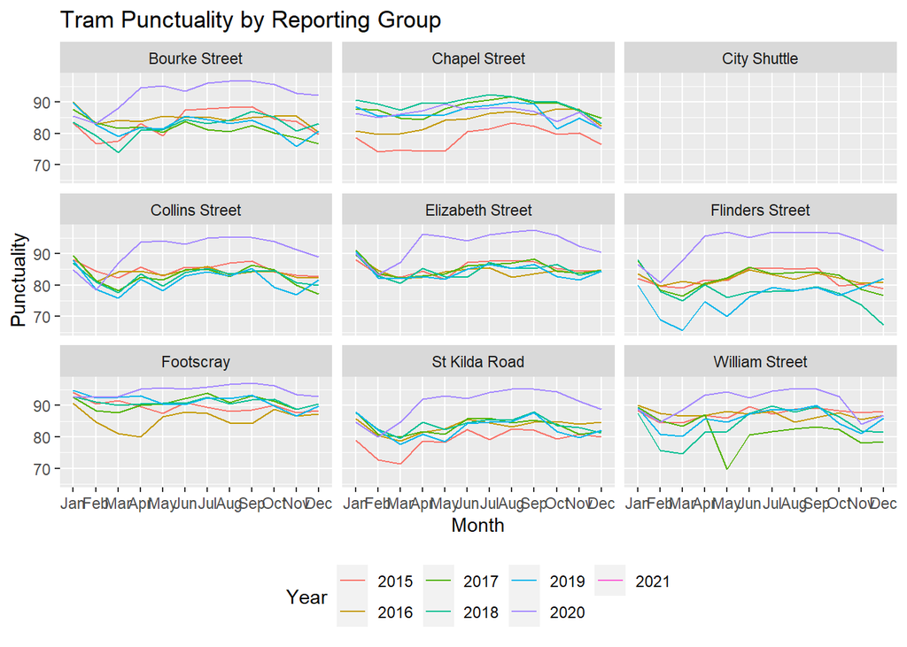

```r
dplyr::filter(perf_group,Service_Year >= 2015  & Mode=="Yarra" & Measure=="Punctuality") %>%
  ggplot(
  aes(x=factor(month.abb[Service_Month],levels=month.abb),
      y=value, colour=as.character(Service_Year),
      group= Service_Year))+geom_line() +
  facet_wrap(~Reporting_Group) +
  labs(x="Month", y="Punctuality", colour="Year",
  title="Tram Punctuality by Reporting Group") +theme(legend.position = "bottom")
```

## 🚋 VLine Performance 2020 compared to previous years

**Question: Which Reporting_Group had a month of very poor punctuality in 2020 for V/Line? Alter your code from the previous question**

- Hint: Filter by VLine, then as before:
- use group = Service_Year, filter the data >=2015
- Hint: Use facet_wrap(~Reporting_Group)
- Hint: Filter for Punctuality values only

**Answer: North Eastern group had poor punctuality in March 2020**

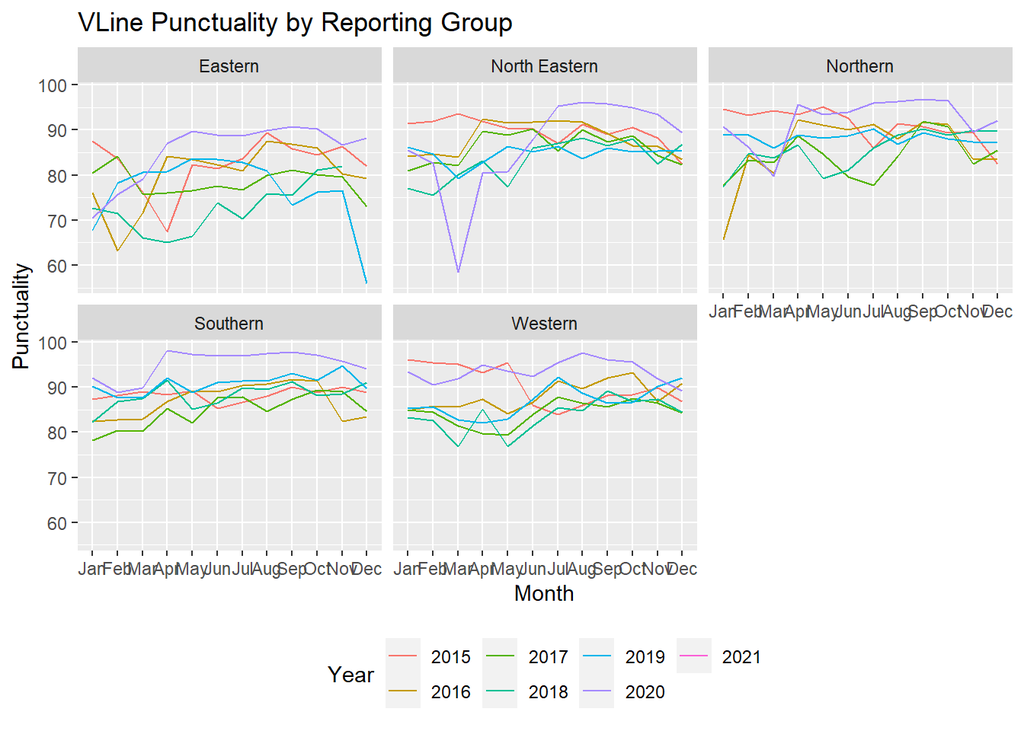

```r
dplyr::filter(perf_group,Service_Year >= 2015 & Mode=="VLine" & Measure=="Punctuality") %>%
  ggplot(
  aes(x=factor(month.abb[Service_Month],levels=month.abb), y=value, colour=as.character(Service_Year),
      group= Service_Year))+geom_line() +
  facet_wrap(~Reporting_Group) + labs(x="Month", y="Punctuality", colour="Year",
      title="VLine Punctuality by Reporting Group") +theme(legend.position = "bottom")
```